# act_report

## Report: act_report

### Analyzing and Visualizing Data

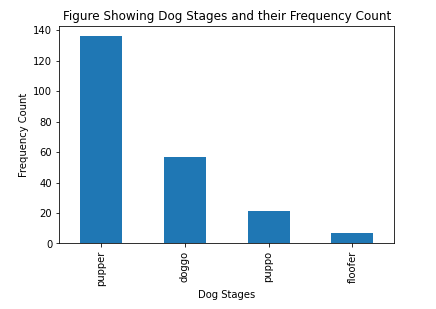

According to dogtionary definition, a pupper is a small doggo usually younger than doggo and can be equally matured if not more matured than some doggos. They are inexperienced, unfamiliar or in any way unprepared for the responsibilities associated with a doggo. Below is a sample picture of a typical pupper.

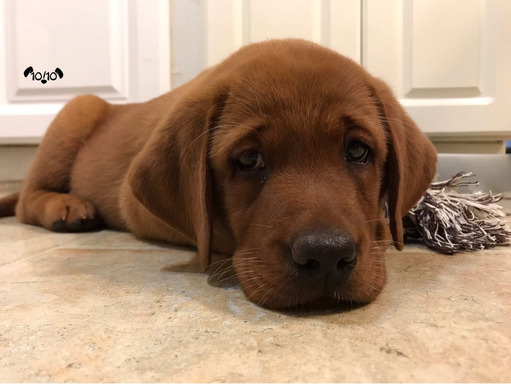

According to dogtionary definition, a doggo is a big pupper usually older but sometimes behave like a pupper. It appears to have its life in order and probably understands taxes and whatnot. Below is a sample picture of a typical doggo.

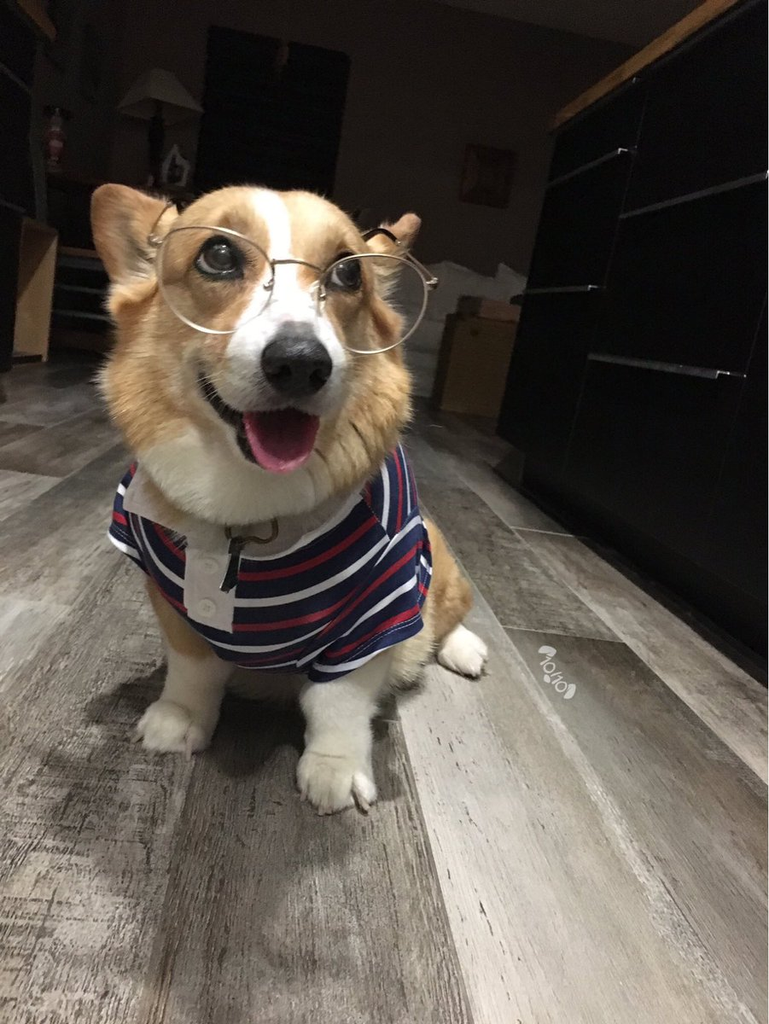

According to dogtionary definition, a puppo is a transitional phase between pupper and doggo and easily understood as the dog equivalent of a teenager. It is a dog with a mixed bag of both pupper and doggo tendencies. Below is a sample picture of a typical puppo.

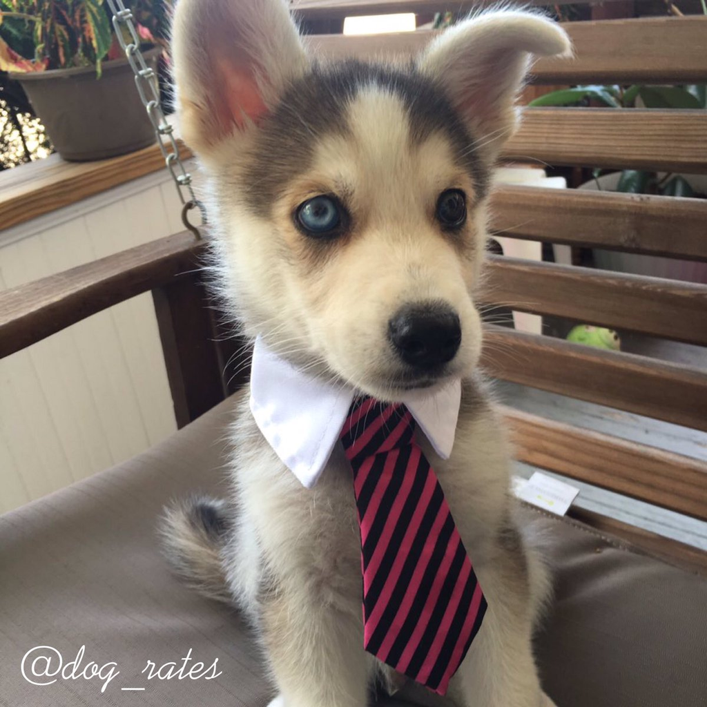

According to dogtionary definition, a floofer is any dog really but commonly given to dogs with seemingly excessive fur. Comical amount of fur on a dog will certainly earn the dog this generic name. Below is a sample picture of a floofer.

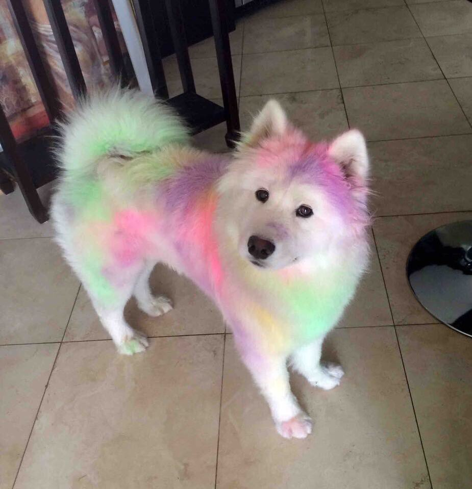

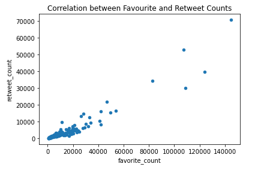

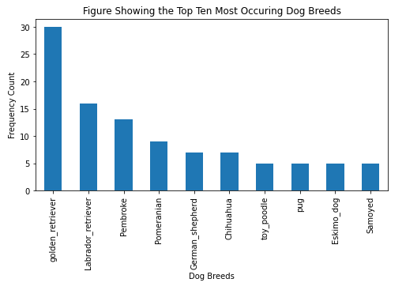